# Learning ML with Titanic Survival

Deepak Kumar G S

November 23, 2017

# Introduction

- As is the case with every programming language, this **Titanic:Machine Learning from Disaster** has become the *Hello World !* to machine learning.Therefore I try my hands on this dataset to begin my journey into the field of machine learning.
- I intend to do exploratory data analysis,missing value imputation on the dataset and then implement predictive modelling ,cross validate with test data and make the submission.Lets begin the journey.

# Loading the libraries and dataset

```r
library(dplyr)
library(ggplot2)
library(ggthemes)
library(corrplot)
library(rpart)
library(randomForest)
library(pscl)
library(Deducer)
library(Amelia)
library(forcats)
library(Hmisc)
library(VIM)
library(rpart.plot)
train=read.csv("train.csv",header=TRUE,stringsAsFactors = FALSE)
test=read.csv("test.csv",header=TRUE,stringsAsFactors = FALSE)
```

# Glimpse of the data:

We then use the *summary* function on the dataset to understand the variable type and missing values.

```r
cat("There are ",nrow(train),"rows and",ncol(train),"columns in train dataset")
```

```
## There are  891 rows and 12 columns in train dataset
```

```r
cat("There are",nrow(test),"rows and",ncol(train),"columns in test dataset")
```

```
## There are 418 rows and 12 columns in test dataset
```

```r
summary(train)
```

```
##   PassengerId       Survived          Pclass          Name
##  Min.   :  1.0   Min.   :0.0000   Min.   :1.000   Length:891
##  1st Qu.:223.5   1st Qu.:0.0000   1st Qu.:2.000   Class :character
##  Median :446.0   Median :0.0000   Median :3.000   Mode  :character
##  Mean   :446.0   Mean   :0.3838   Mean   :2.309
##  3rd Qu.:668.5   3rd Qu.:1.0000   3rd Qu.:3.000
##  Max.   :891.0   Max.   :1.0000   Max.   :3.000
##
##      Sex                 Age            SibSp           Parch
##  Length:891         Min.   : 0.42   Min.   :0.000   Min.   :0.0000
##  Class :character   1st Qu.:20.12   1st Qu.:0.000   1st Qu.:0.0000
##  Mode  :character   Median :28.00   Median :0.000   Median :0.0000
##                     Mean   :29.70   Mean   :0.523   Mean   :0.3816
##                     3rd Qu.:38.00   3rd Qu.:1.000   3rd Qu.:0.0000
##                     Max.   :80.00   Max.   :8.000   Max.   :6.0000
##                     NA's   :177
##     Ticket               Fare           Cabin             Embarked
##  Length:891         Min.   :  0.00   Length:891         Length:891
##  Class :character   1st Qu.:  7.91   Class :character   Class :character
##  Mode  :character   Median : 14.45   Mode  :character   Mode  :character
##                     Mean   : 32.20
##                     3rd Qu.: 31.00
##                     Max.   :512.33
##
```

```r
summary(test)
```

```
##   PassengerId         Pclass          Name               Sex
##  Min.   : 892.0   Min.   :1.000   Length:418         Length:418
##  1st Qu.: 996.2   1st Qu.:1.000   Class :character   Class :character
##  Median :1100.5   Median :3.000   Mode  :character   Mode  :character
##  Mean   :1100.5   Mean   :2.266
##  3rd Qu.:1204.8   3rd Qu.:3.000
##  Max.   :1309.0   Max.   :3.000
##
##       Age            SibSp            Parch           Ticket
##  Min.   : 0.17   Min.   :0.0000   Min.   :0.0000   Length:418
##  1st Qu.:21.00   1st Qu.:0.0000   1st Qu.:0.0000   Class :character
##  Median :27.00   Median :0.0000   Median :0.0000   Mode  :character
##  Mean   :30.27   Mean   :0.4474   Mean   :0.3923
##  3rd Qu.:39.00   3rd Qu.:1.0000   3rd Qu.:0.0000
##  Max.   :76.00   Max.   :8.0000   Max.   :9.0000
##  NA's   :86
##       Fare            Cabin             Embarked
##  Min.   :  0.000   Length:418         Length:418
##  1st Qu.:  7.896   Class :character   Class :character
##  Median : 14.454   Mode  :character   Mode  :character
##  Mean   : 35.627
##  3rd Qu.: 31.500
##  Max.   :512.329
##  NA's   :1
```

**Train Dataset** - From the train summary it is clear that *Age* has 177 missing values.For a visually appealing view of the NA values,we use *missmap* from the library *Amelia*.For documentation refer this [link](https://r.iq.harvard.edu/docs/amelia/amelia.pdf).

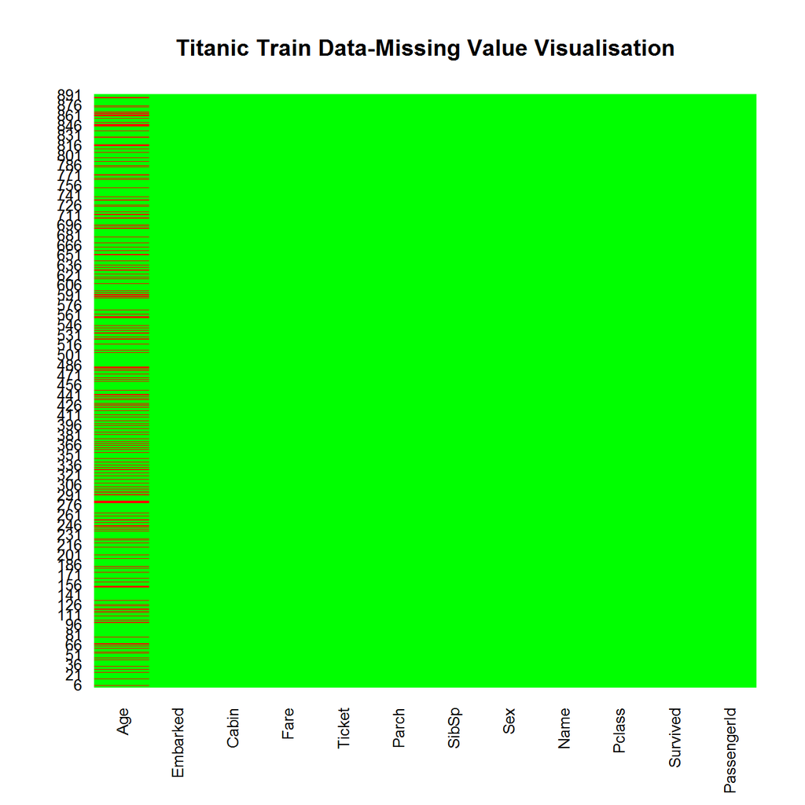

```r
missmap(train,main="Titanic Train Data-Missing Value Visualisation",col=c("red","green"),legend=FALSE)
```

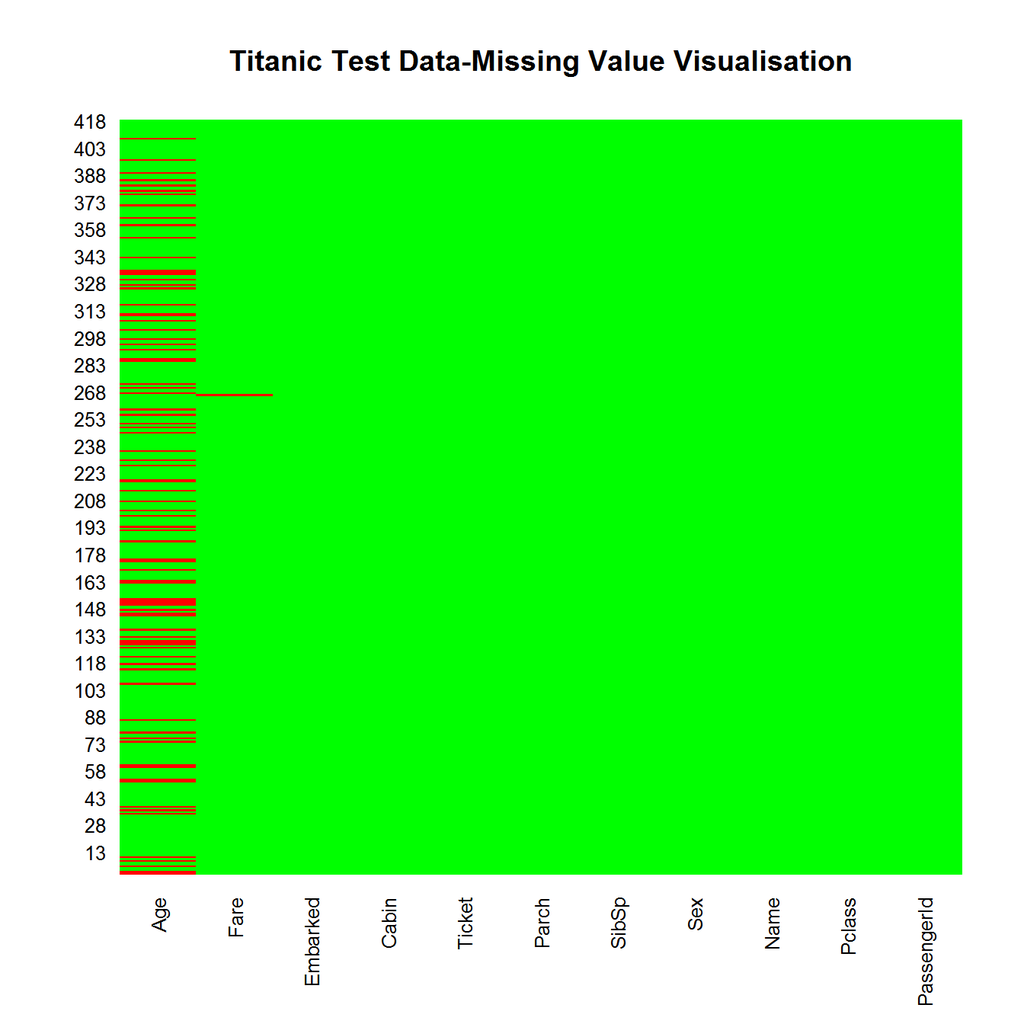

```r
missmap(test,main="Titanic Test Data-Missing Value Visualisation",col=c("red","green"),legend=FALSE)
```

From the missing value visualisation of train data,it is understood that Age has most missing values whereas in test dataset one row in fare is missing in addition to Age.

Now let us comine both the train and test data to do some EDA.

```r
titanic=full_join(train,test)
summary(titanic)
```

```
##   PassengerId      Survived          Pclass          Name
##  Min.   :   1   Min.   :0.0000   Min.   :1.000   Length:1309
##  1st Qu.: 328   1st Qu.:0.0000   1st Qu.:2.000   Class :character
##  Median : 655   Median :0.0000   Median :3.000   Mode  :character
##  Mean   : 655   Mean   :0.3838   Mean   :2.295
##  3rd Qu.: 982   3rd Qu.:1.0000   3rd Qu.:3.000
##  Max.   :1309   Max.   :1.0000   Max.   :3.000
##                 NA's   :418
##      Sex                 Age            SibSp            Parch
##  Length:1309        Min.   : 0.17   Min.   :0.0000   Min.   :0.000
##  Class :character   1st Qu.:21.00   1st Qu.:0.0000   1st Qu.:0.000
##  Mode  :character   Median :28.00   Median :0.0000   Median :0.000
##                     Mean   :29.88   Mean   :0.4989   Mean   :0.385
##                     3rd Qu.:39.00   3rd Qu.:1.0000   3rd Qu.:0.000
##                     Max.   :80.00   Max.   :8.0000   Max.   :9.000
##                     NA's   :263
##     Ticket               Fare            Cabin
##  Length:1309        Min.   :  0.000   Length:1309
##  Class :character   1st Qu.:  7.896   Class :character
##  Mode  :character   Median : 14.454   Mode  :character
##                     Mean   : 33.295
##                     3rd Qu.: 31.275
##                     Max.   :512.329
##                     NA's   :1
##    Embarked
##  Length:1309
##  Class :character
##  Mode  :character
##
##
##
##
```

# Missing value imputation

Let us first focus on the missing value imputation and do some visual exploration after that.We first consider the age.

## Age

```r
prop.table(table(is.na(titanic$Age)))
```

```
##
##     FALSE      TRUE
## 0.7990833 0.2009167
```

20 % of the values in the Age column is missing.Therefore we use the **rpart (recursive partitioning)** to impute the age values.

```r
age=rpart(Age ~Pclass+Sex+SibSp+Parch+Fare+Embarked,data=titanic[!(is.na(titanic$Age)),],method="anova")
titanic$Age[is.na(titanic$Age)]=predict(age,titanic[is.na(titanic$Age),])
```

Let us check ,

```r
prop.table(table(is.na(titanic$Age)))
```

```
##
## FALSE
##     1
```

The column does not have any missing values.

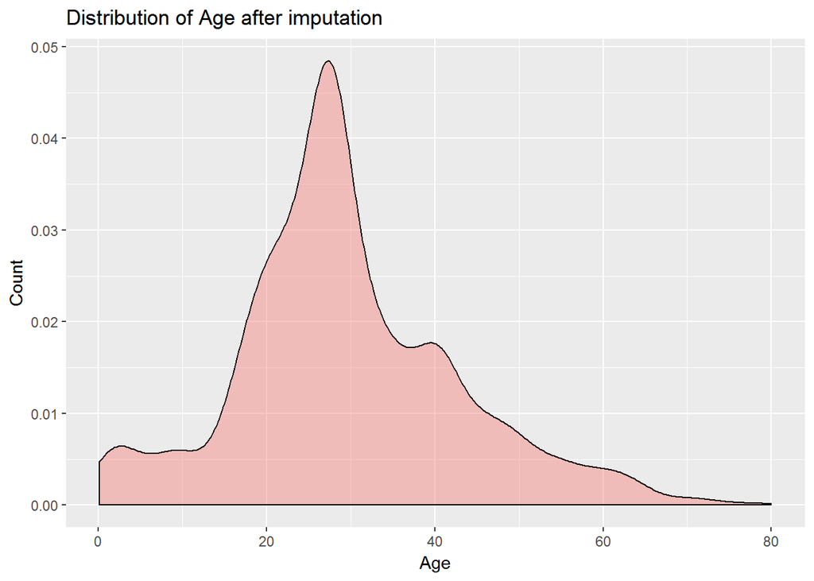

```r
ggplot(titanic,aes(Age,fill="green"))+geom_density(alpha=0.4)+labs(x="Age",y="Count",title="Distribution of Age after imputation")+theme(legend.position="none")
```

# Fare:

```r
cat("There is",sum(is.na(titanic$Fare)),"missing value in Fare")
```

```
## There is 1 missing value in Fare
```

We find out the row and the details.

```r
which(is.na(titanic$Fare))
```

```
## [1] 1044
```

```r
titanic[1044,]
```

```
##      PassengerId Survived Pclass               Name  Sex  Age SibSp Parch
## 1044        1044       NA      3 Storey, Mr. Thomas male 60.5     0     0
##      Ticket Fare Cabin Embarked
## 1044   3701   NA              S
```

The passenger belongs to 3rd class and has emparked on S.The passenger is male.We again use the *rpart* function for imputation.

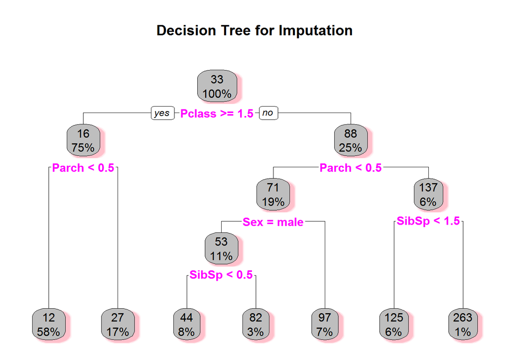

```r
fare=rpart(Fare ~Parch+SibSp+Sex+Pclass,data=titanic[!(is.na(titanic$Fare)),],method="anova")
titanic$Fare[(is.na(titanic$Fare))]=predict(fare,data=titanic[is.na(titanic$Fare),])
rpart.plot(fare,shadow.col="pink",box.col="gray",split.col="magenta",main="Decision Tree for Imputation")
```

From the decision tree,we interpret that passengers in 2nd or 3rd class paid lesser compared to 1st class and those having parents or childrens shelled out more compared to those who travelled alone.

```r
prop.table(table(is.na(titanic$Fare)))
```

```
##
## FALSE
##     1
```

We plot the density plot to understand about the fare dynamics.

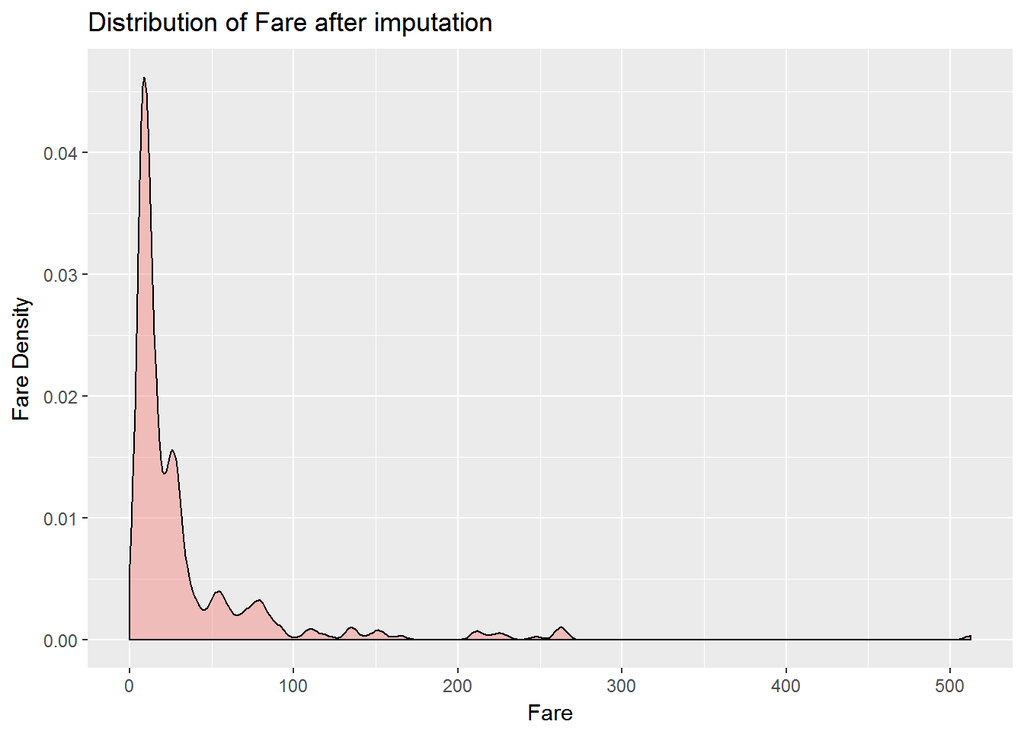

```r
ggplot(titanic,aes(Fare,fill="green"))+geom_density(alpha=0.4)+labs(x="Fare",y="Fare Density",title="Distribution of Fare after imputation")+theme(legend.position="none")
```

Clearly we see that the data is highly skewed towards right. # Data Wrangling and Visualisation:

We now focus on the name,sex,SibSp,Parch,Pclass to do some data wrangling and visualisation.We start with name.

```r
str(titanic$Name)
```

```
##  chr [1:1309] "Braund, Mr. Owen Harris" ...
```

For better understanding of the data we extract the title from the Name.

```r
titanic$Title=gsub('(.*, )|(\\..*)','',titanic$Name)
head(titanic$Title)
```

```
## [1] "Mr"   "Mrs"  "Miss" "Mrs"  "Mr"   "Mr"
```

```r
table(titanic$Title,titanic$Sex)
```

```
##
##                female male
##   Capt              0    1
##   Col               0    4
##   Don               0    1
##   Dona              1    0
##   Dr                1    7
##   Jonkheer          0    1
##   Lady              1    0
##   Major             0    2
##   Master            0   61
##   Miss            260    0
##   Mlle              2    0
##   Mme               1    0
##   Mr                0  757
##   Mrs             197    0
##   Ms                2    0
##   Rev               0    8
##   Sir               0    1
##   the Countess      1    0
```

We convert the variable into factor and using function from *forcats* library we collapse some of these levels.Following code is inspired from [Andrew Kinsman](https://www.kaggle.com/varimp/a-mostly-tidyverse-tour-of-the-titanic).

```r
titanic <- titanic %>% mutate(Title = factor(Title)) %>% mutate(Title = fct_collapse(Title, "Miss" = c("Mlle", "Ms"), "Mrs" = "Mme", "Ranked" = c( "Major", "Dr", "Capt", "Col", "Rev"),"Royalty" = c("Lady", "Dona", "the Countess", "Don", "Sir", "Jonkheer")))
str(titanic$Title)
```

```
##  Factor w/ 6 levels "Ranked","Royalty",..: 6 5 4 5 6 6 6 3 5 5 ...
```

Next we create a column called Family to know who all have travelled alone and who travelled with their families.This is achieved through simple ifelse statement where the condition will be *if a person has travelled with parents/children or sibling/spouse then the statement will be evaluated as true else it is false*.

```r
titanic$Families= factor(ifelse(titanic$SibSp + titanic$Parch + 1> 1,"Yes","No"))
prop.table(table(titanic$Families))
```

```
##
##        No       Yes
## 0.6035141 0.3964859
```

Almost 40 % of them have travelled with families.

Now let us look at the passenger class.

```r
prop.table(table(titanic$Pclass))
```

```
##
##         1         2         3
## 0.2467532 0.2116119 0.5416348
```

54 % of them have travelled in third class whereas an 25 % of them have been in 1st class.Let us compare the survival rates

## Surival Scenario

```r
titanic=titanic %>% mutate(Survived=factor(Survived)) %>% mutate(Survived=fct_recode(Survived,"No"="0","Yes"="1"))
# train=titanic[1:891,]
# test=titanic[1:1309,]
prop.table(table(train$Survived))
```

```
##
##         0         1
## 0.6161616 0.3838384
```

In the train data, only 38 % have survived whereas 61 % have perished.Lets dig deeper and see the trend.

## By Gender

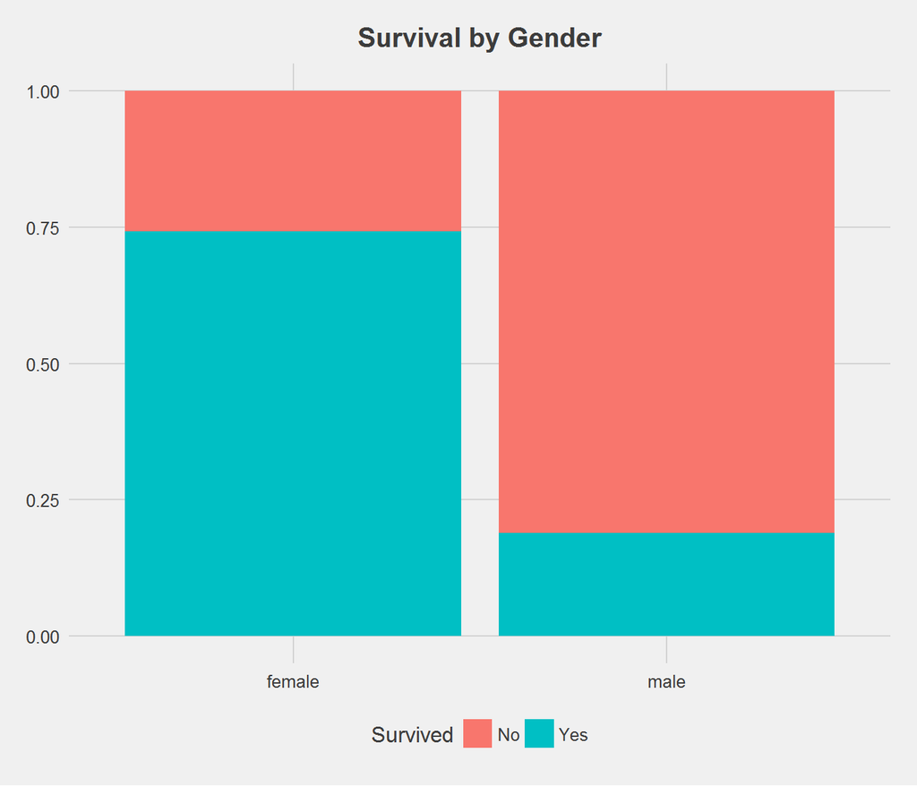

```r
ggplot(titanic[1:891,],aes(Sex,fill=Survived))+geom_bar(position="fill")+theme_fivethirtyeight()+theme(legend.position="bottom",plot.title=element_text(size=15,hjust=0.5))+labs(x="Gender",y="Survival Rate",title="Survival by Gender")
```

On board Titanic,the chances of survival being a male is very less whereas for female it is subtantially greater.This indicates that there was gender disparity in the ship while saving lives.Let us see the passenger class.

### By Passenger Class

```r
str(titanic$Pclass)
```

```
##  int [1:1309] 3 1 3 1 3 3 1 3 3 2 ...
```

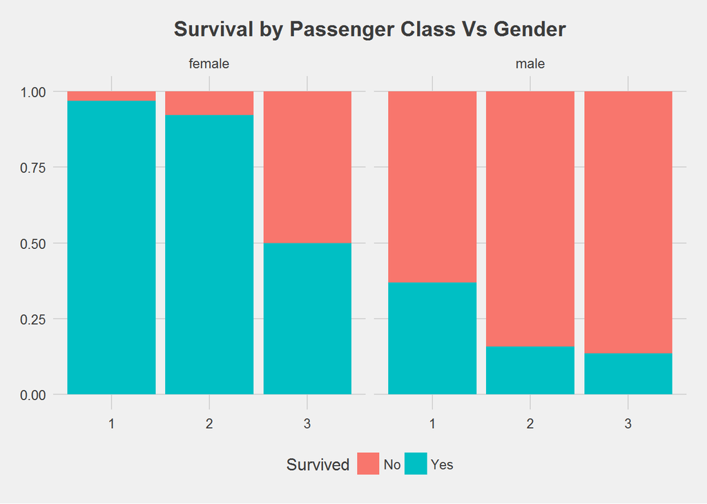

```r
ggplot(titanic[1:891,],aes(Pclass,fill=Survived))+geom_bar(position="fill")+facet_wrap(~Sex)+theme_fivethirtyeight()+theme(legend.position="bottom",plot.title=element_text(size=15,hjust=0.5))+labs(x="Passenger Class",y="Survival Rate",title="Survival by Passenger Class Vs Gender")
```

From the two plots,it is understood that irrespective of the gender,there is a higher chance of survival if you were from 1st class.But,if you happen to be female 1st class passenger,then the chances of survival increases subtantially.Those who are unlucky are people from 2nd and 3rd class for male.

### By Title

Let us understand the scenario with the Title and survival rate.

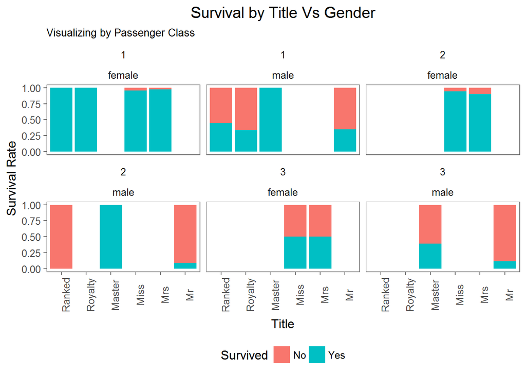

```r
ggplot(titanic[1:891,],aes(Title,fill=Survived))+geom_bar(position="fill")+facet_wrap(Pclass~Sex)+theme_few()+theme(legend.position="bottom",plot.title=element_text(size=15,hjust=0.5),plot.subtitle = element_text(size=10),axis.text.x=element_text(angle=90))+labs(x="Title",y="Survival Rate",title="Survival by Title Vs Gender",subtitle="Visualizing by Passenger Class")
```

### By Embarkment:

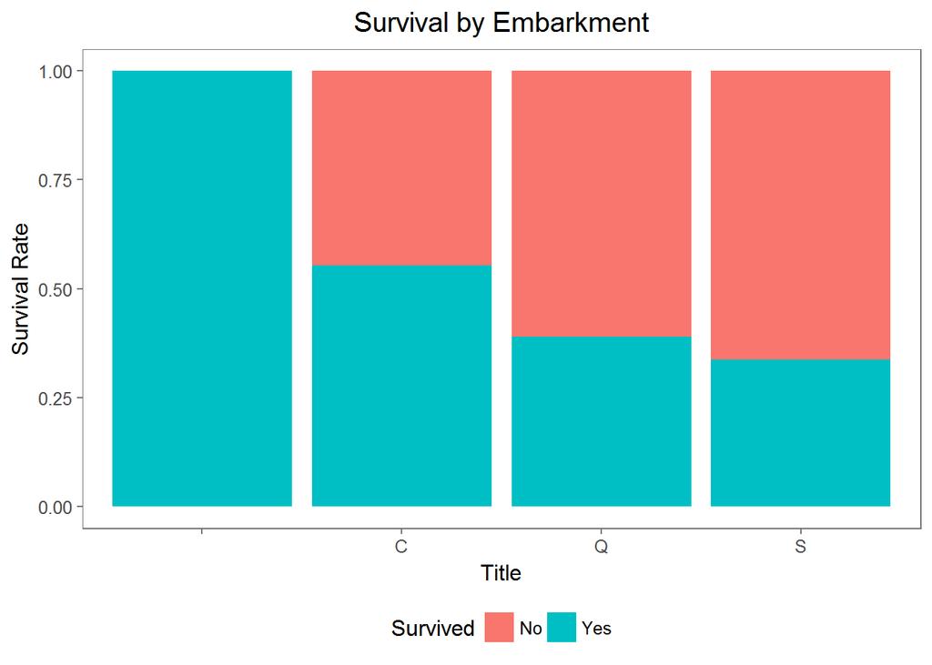

```r
ggplot(titanic[1:891,],aes(Embarked,fill=Survived))+geom_bar(position="fill")+theme_few()+theme(legend.position="bottom",plot.title=element_text(size=15,hjust=0.5))+labs(x="Title",y="Survival Rate",title="Survival by Embarkment")
```

There seems to be one row with no value for embarkmemt.let us add this to the majority class.

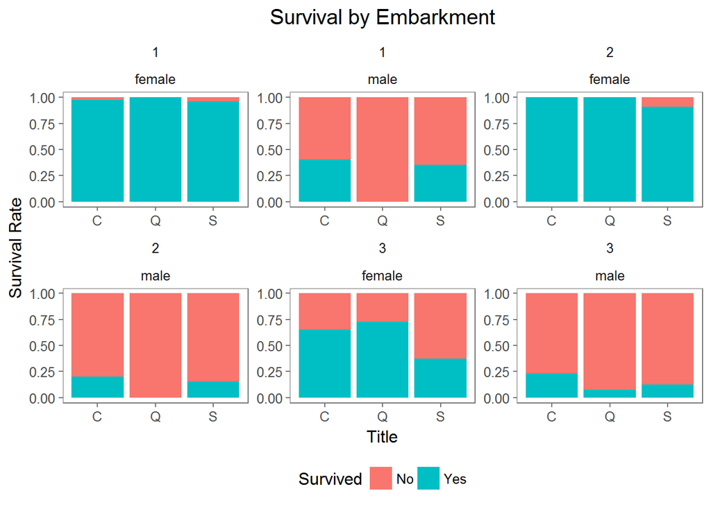

```r
titanic =titanic %>% mutate(Embarked=ifelse(Embarked=="",names(which.max(table(titanic$Embarked))),Embarked))
ggplot(titanic[1:891,],aes(Embarked,fill=Survived))+geom_bar(position="fill")+theme_few()+theme(legend.position="bottom",plot.title=element_text(size=15,hjust=0.5))+labs(x="Title",y="Survival Rate",title="Survival by Embarkment")+facet_wrap(Pclass~Sex,scales="free")
```

### By Families:

Let us now focus on the survival rates with respect to family.

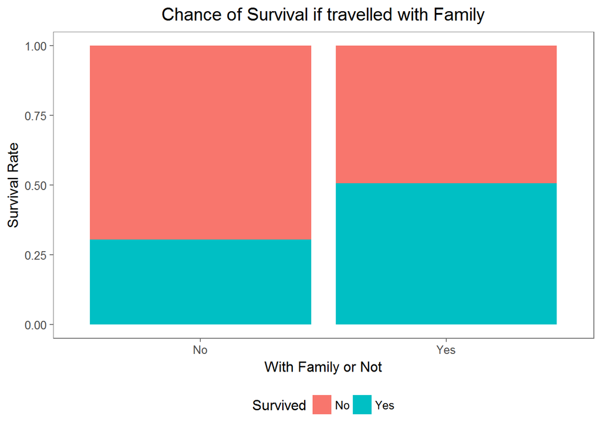

```r
ggplot(titanic[1:891,],aes(Families,fill=Survived))+geom_bar(position="fill")+theme_few()+theme(legend.position="bottom",plot.title=element_text(size=15,hjust=0.5))+labs(x="With Family or Not",y="Survival Rate",title="Chance of Survival if travelled with Family")
```

- The chances of survival seems to be a bit higher for those who travel with their families.

### Median age of Survival

Let us draw a boxplot to understand the median age of survival with respect to gender.

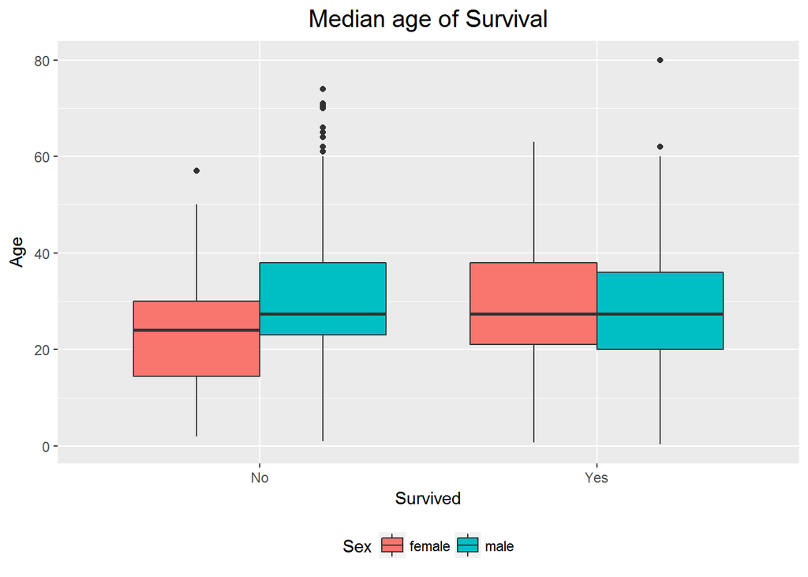

```r
ggplot(titanic[1:891,],aes(Survived,Age,fill=Sex))+geom_boxplot()+theme(legend.position="bottom",plot.title=element_text(size=15,hjust=0.5))+labs(x="Survived",y="Age",title="Median age of Survival")
```